# Topics emphasized in the curriculums for history 1960-2019

Kirstine_Thorhauge-Ravnholt

2/1/2023

The following contains the code and the data for my project. The goal of the project is to get a rough idea of which themes have been emphasized in the laws about the educational system through the years

#Using the following packages In order to create the code I need in my project, I use the following packages:

```r
#install.packages("pdftools")
#install.packages('data.table')

library ("tidyverse")
library ("here")
```

```
## here() starts at /Users/kirstinethorhauge-ravnholt/Documents/5. semester/Reeksamen/HistorySubjectAnalysis
```

```r
library ("tidytext")
library ("readr")
library ("forcats")
library ("dplyr")
library ("widyr")
library ("stopwords")
library ("pdftools")
```

```
## Using poppler version 22.02.0
```

```r
library ("data.table")
```

# structuring the project

```r
# dir.create("data")
```

#Loading the data The pdftools package is used to extract the text from the pdf files, using the method pdf_text. It is converted into a list of lines using strsplit(), and these lines are further converted into a vector containing these lines by using unlist(). I use the data.format - function to make a table containing a column for year and a column for the corresponding vector, containing the lines of text.

```r
lines_1960 <- unlist(strsplit(pdf_text("data/Educational_Goals/1960-historie.pdf"), "\n"))
table_1960 <- data.frame(text=lines_1960, year="1960")
lines_1974 <- unlist(strsplit(pdf_text("data/Educational_Goals/1974-historie.pdf"), "\n"))
table_1974 <- data.frame(text=lines_1974, year="1974")
lines_1977 <- unlist(strsplit(pdf_text("data/Educational_Goals/1977-historie.pdf"), "\n"))
table_1977 <- data.frame(text=lines_1977, year="1977")
lines_1981 <- unlist(strsplit(pdf_text("data/Educational_Goals/1981-historie.pdf"), "\n"))
table_1981 <- data.frame(text=lines_1981, year="1981")
lines_1984 <- unlist(strsplit(pdf_text("data/Educational_Goals/1984-historie.pdf"), "\n"))
table_1984 <- data.frame(text=lines_1984, year="1984")
lines_1995 <- unlist(strsplit(pdf_text("data/Educational_Goals/1995-historie.pdf"), "\n"))
table_1995 <- data.frame(text=lines_1995, year="1995")
lines_2002 <- unlist(strsplit(pdf_text("data/Educational_Goals/2002-historie.pdf"), "\n"))
table_2002 <- data.frame(text=lines_2002, year="2002")
lines_2004 <- unlist(strsplit(pdf_text("data/Educational_Goals/2004-historie.pdf"), "\n"))
table_2004 <- data.frame(text=lines_2004, year="2004")
lines_2009 <- unlist(strsplit(pdf_text("data/Educational_Goals/2009-historie.pdf"), "\n"))
table_2009 <- data.frame(text=lines_2009, year="2009")
lines_2015 <- unlist(strsplit(pdf_text("data/Educational_Goals/2015-historie.pdf"), "\n"))
table_2015 <- data.frame(text=lines_2015, year="2015")
lines_2019 <- unlist(strsplit(pdf_text("data/Educational_Goals/2019-historie.pdf"), "\n"))
table_2019 <- data.frame(text=lines_2019, year="2019")

history_goals <- rbind(table_1960, table_1974, table_1977, table_1981, table_1984, table_1995, table_2002, table_2004, table_2009, table_2015, table_2019)
```

#creating the stopwords It’s important to remove the most common danish words. I use the stopwordpackage: stopwords. This package contains stopwordslists in multiple languages. I first install the package. The “da” is to specify that I want to use the danish stopwordlist. There are different variations of stopwordlists avaliable. I chose this one because it’s aviable in the largest amount of languages. I use the data.frame - function to turn it into a table, since that’s the is needed later in the code.

Other than removing the most common danish words, I noticed that the premade danish stopword list did not include some very common abbreviations and some words commonly used in more technical texts (such as “f.eks.” “fx.” and “m.” - the common abbreviations for “for example” and “with” and like “fig” for figure). I therefore added these stopwords to the stopwordlist.

```r
#install.packages("stopwords")
library("stopwords")
stopwords_getsources()
```

```
## [1] "snowball"      "stopwords-iso" "misc"          "smart"
## [5] "marimo"        "ancient"       "nltk"          "perseus"
```

```r
DanishStopwords<-c(stopwords("da", source="stopwords-iso"), "f", "x", "fx", "eks", "f.eks", "ca", "m", "fig", "for-")

DanishStopwordsTable<-data.frame("word" = DanishStopwords)
```

#Which words stands out? Tidytext and tidyverse, as the names suggest, are made to make data tidy and ready for analysis. I use the unnest_tokens() function to divide the text I have in my data frame into individual words. I use the filter() method from the dplyr package to only include words that do not appear in my stopwords list. Then I use the count() method to count the amount of times each word has been used. This way I get a table with each word and the amount of time it has been used each year. All the years are combined into one table using rbind(). I then make a new table called dataset total_history_words. By grouping it by year and using the summarise(total=sum(n)) method, I get a column with the year and a column with the amount of total words used that year. Using left_join() I then include these new columns in the history_goals_words table that I made previously. The bind_tf_idf() function is used to create a statistic that account for both the frequency of the word in a certain text and how much it is used in other the other texts - the higher the frequency in one text as compared to other, the higher the “importance” of the word.

```r
history_goals_words <- history_goals %>%
  unnest_tokens(word,text) %>%
  filter(!word %in% DanishStopwordsTable$word) %>%
  count(year,word,sort=TRUE)

total_history_goals_words <- history_goals_words %>% group_by(year) %>% summarize(total=sum(n))

history_goals_words <-left_join(history_goals_words, total_history_goals_words)
history_goals_tf_idf <- history_goals_words %>% bind_tf_idf(word,year,n)
```

#Visualising the data In order to make the data easily legible, I use a ggplot to visualise the data by making a bar chart that shows the most frequent words. I do this by grouping the results by year, using the filter() method to choose some of the years that I want to show, and using the slicemax() method to only include the top ten words. It is important to note that I did not worry much about the x-axis having different intervals, which means each chart must be read separately in order to compare the values correctly.

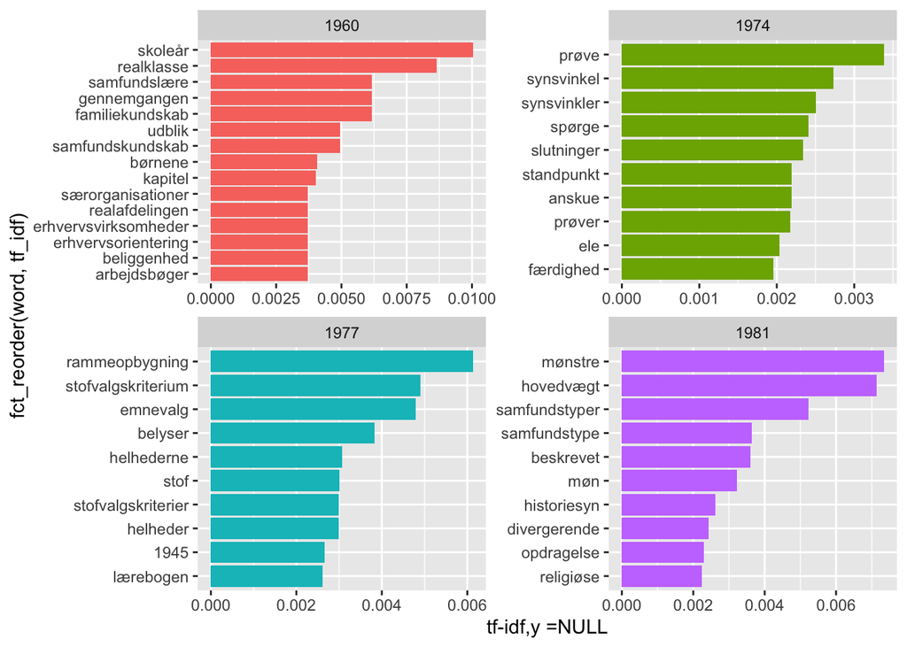

```r
history_goals_tf_idf %>%
  group_by (year) %>%
  filter(year == 1960 | year == 1974 | year == 1977 | year == 1981) %>%
  slice_max(tf_idf, n = 10) %>%
  ungroup() %>%
  ggplot(aes(tf_idf, fct_reorder(word, tf_idf),fill=year)) +
  geom_col(show.legend = FALSE) +
  facet_wrap(~year, ncol=2,scales="free") +
  labs(x="tf-idf,y =NULL")
```

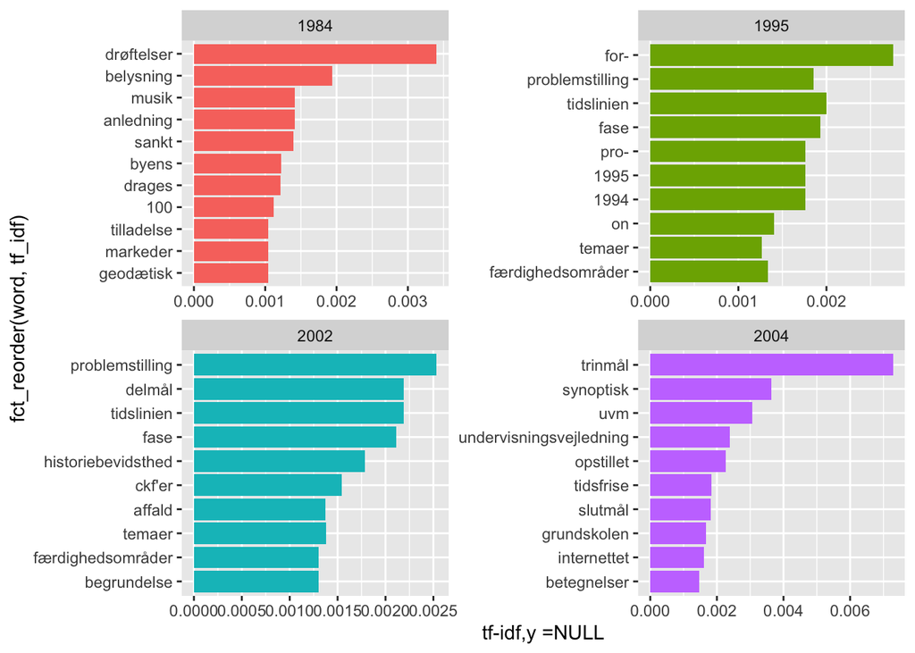

```r
history_goals_tf_idf %>%
  group_by (year) %>%
  filter(year == 1984 | year == 1995 | year == 2002 | year == 2004) %>%
  slice_max(tf_idf, n = 10) %>%
  ungroup() %>%
  ggplot(aes(tf_idf, fct_reorder(word, tf_idf),fill=year)) +
  geom_col(show.legend = FALSE) +
  facet_wrap(~year, ncol=2,scales="free") +
  labs(x="tf-idf,y =NULL")
```

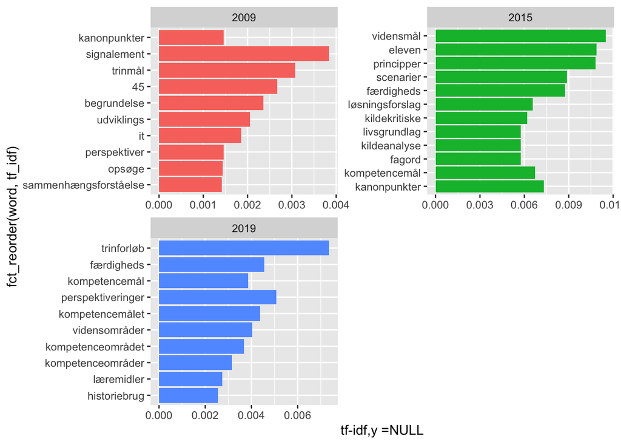

```r
history_goals_tf_idf %>%
  group_by (year) %>%
  filter(year == 2009 | year == 2015 | year == 2019) %>%
  slice_max(tf_idf, n = 10) %>%
  ungroup() %>%
  ggplot(aes(tf_idf, fct_reorder(word, tf_idf),fill=year)) +
  geom_col(show.legend = FALSE) +
  facet_wrap(~year, ncol=2,scales="free") +
  labs(x="tf-idf,y =NULL")
```